# TP 4 : Matrices et listes

Andrea Andreoli

2026-11-17

# Partie A : Construire et manipuler des matrices

## A1

```r
# Création de A (remplie par colonne par défaut) et B (remplie par ligne)
A <- matrix(1:25, nrow = 5, ncol = 5)
B <- matrix(1:25, nrow = 5, ncol = 5, byrow = TRUE)

# Vérification en une seule instruction que B est la transposée de A
identical(B, t(A))
```

```
## [1] TRUE
```

```r
# Nommage des lignes et des colonnes de B
rownames(B) <- paste0("L", 1:5)
colnames(B) <- paste0("C", 1:5)

# a. 3e colonne de B
B[, 3]
```

```
## L1 L2 L3 L4 L5
##  3  8 13 18 23
```

```r
# b. Lignes 1 et 5 de B
B[c(1, 5), ]
```

```
##    C1 C2 C3 C4 C5
## L1  1  2  3  4  5
## L5 21 22 23 24 25
```

```r
# c. Colonne C1 par son nom sous forme de matrice (drop = FALSE)
B[, "C1", drop = FALSE]
```

```
##    C1
## L1  1
## L2  6
## L3 11
## L4 16
## L5 21
```

## A2

```r
# Fixation de la graine aléatoire pour la reproductibilité
set.seed(4)

# Tirage selon N(mu = 3, sigma^2 = 10) -> l'écart-type sd vaut sqrt(10)
X <- matrix(rnorm(36, mean = 3, sd = sqrt(10)), nrow = 6, ncol = 6)

# a. Nombre d'éléments strictement supérieurs à 3
nb_sup3 <- sum(X > 3)

# b. Positions (ligne, colonne) du minimum et du maximum
pos_min <- which(X == min(X), arr.ind = TRUE)
pos_max <- which(X == max(X), arr.ind = TRUE)

# c. Création de X01 en une seule instruction et vérification de ses dimensions/classe
X01 <- ifelse(X > 3, 1, 0)
is.matrix(X01)
```

```
## [1] TRUE
```

```r
dim(X01)
```

```
## [1] 6 6
```

- **a.** La matrice `X` contient **24 éléments** strictement supérieurs à 3[cite: 2].
- **b.** Le minimum ($-1.69$) se trouve à la position **(ligne 4, colonne 6)**, et le maximum ($9$) se situe à la position **(ligne 3, colonne 2)**[cite: 2].
- **c.** L’objet `X01` est bien une matrice (`is.matrix(X01)` vaut TRUE) de dimensions **6 x 6**[cite: 2].

## A3

```r
# a. Calcul des sommes des lignes, colonnes et des deux diagonales de durer
sommes_lignes <- rowSums(durer)
sommes_colonnes <- colSums(durer)
somme_diag <- sum(diag(durer))
somme_antidiag <- sum(diag(durer[, ncol(durer):1]))

sommes_lignes
```

```
## [1] 34 34 34 34
```

```r
sommes_colonnes
```

```
## [1] 34 34 34 34
```

```r
c(diagonale = somme_diag, antidiagonale = somme_antidiag)
```

```
##     diagonale antidiagonale
##            34            34
```

```r
# b. Instruction unique testant si une matrice est magique (appliquée à durer puis candidat)
length(unique(c(rowSums(durer), colSums(durer), sum(diag(durer)), sum(diag(durer[, ncol(durer):1]))))) == 1
```

```
## [1] TRUE
```

```r
length(unique(c(rowSums(candidat), colSums(candidat), sum(diag(candidat)), sum(diag(candidat[, ncol(candidat):1]))))) == 1
```

```
## [1] FALSE
```

```r
# c. Diagnostic de la matrice candidat
rowSums(candidat)
```

```
## [1] 15 15 16
```

```r
colSums(candidat)
```

```
## [1] 15 15 16
```

```r
sum(diag(candidat))
```

```
## [1] 16
```

```r
sum(diag(candidat[, ncol(candidat):1]))
```

```
## [1] 15
```

- **a.** Pour le carré de Dürer, toutes les lignes, toutes les colonnes ainsi que les deux diagonales ont pour somme commune **34**[cite: 2].
- **b.** Le test renvoie **`TRUE`** pour `durer` (c’est un carré magique) et **`FALSE`** pour `candidat`[cite: 2].
- **c.** Dans `candidat`, la constante magique attendue est **15**. Or, la **3e ligne** somme à 16, la **3e colonne** somme à 16, et la **diagonale principale** ($8 + 5 + 3$) somme également à 16. L’intersection de ces trois éléments est la case **(ligne 3, colonne 3)** qui vaut `3` : il faudrait la remplacer par **`2`** pour obtenir un carré magique parfait[cite: 2].

## A4

```r
# Table de multiplication de 1 à 10 avec outer()
table_mult <- outer(1:10, 1:10, "*")

# a. Nombre de produits distincts
nb_distincts <- length(unique(as.vector(table_mult)))

# b. Proportion des cases contenant un nombre pair
prop_pairs <- mean(table_mult %% 2 == 0)

# c. Extraction des valeurs situées strictement au-dessus de la diagonale
valeurs_sup <- table_mult[upper.tri(table_mult, diag = FALSE)]
nb_sup <- length(valeurs_sup)
```

- **a.** La table de multiplication contient **42 produits distincts**[cite: 2].
- **b.** La proportion de cases contenant un nombre pair est de **0.75** (soit **75 %** des 100 cases)[cite: 2].
- **c.** Il y a **45 valeurs** situées strictement au-dessus de la diagonale principale (ce qui correspond bien à $\frac{10 \times 9}{2} = 45$)[cite: 2].

## A5

```r
# a. Altitude maximale et position(s)
alt_max <- max(volcano)
pos_volcano_max <- which(volcano == alt_max, arr.ind = TRUE)
pos_volcano_max
```

```
##      row col
## [1,]  20  31
```

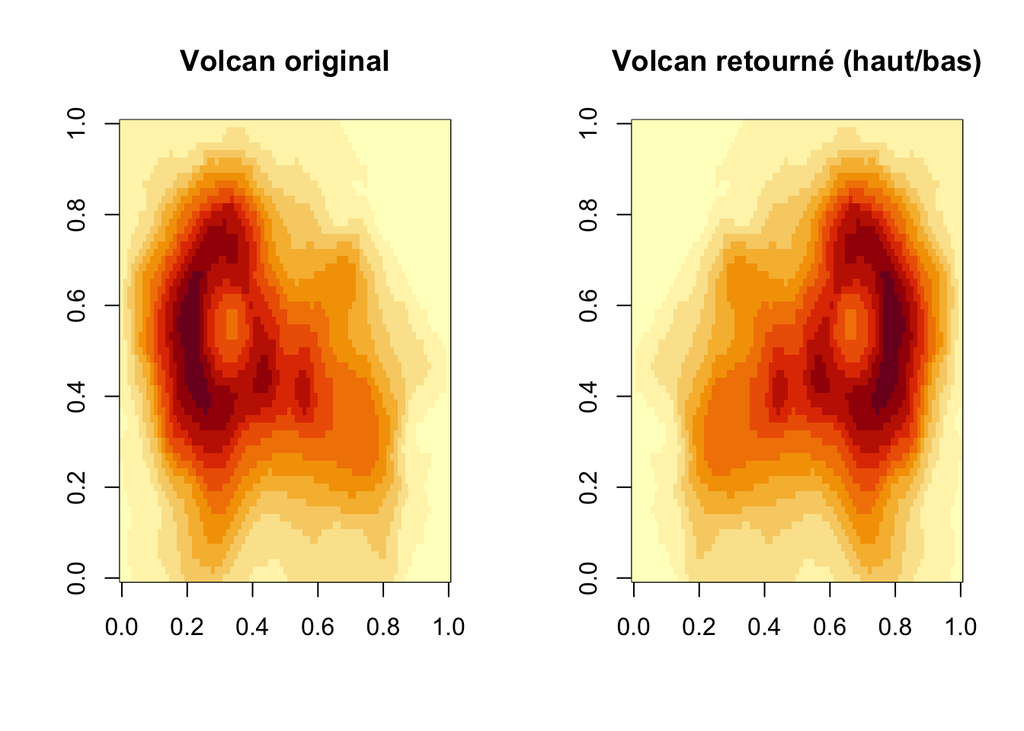

```r
# b. Proportion du terrain au-dessus de 150 m
prop_150 <- mean(volcano > 150)

# c. Ligne ayant l'altitude moyenne la plus élevée
ligne_max_moy <- which.max(rowMeans(volcano))

# d. Dénivelé (max - min) de chaque colonne et colonne au plus fort dénivelé
deniveles <- apply(volcano, 2, function(col) max(col) - min(col))
col_max_denivele <- which.max(deniveles)

# e. Retournement de la matrice de haut en bas et affichage côte à côte
volcano_retourne <- volcano[nrow(volcano):1, ]

par(mfrow = c(1, 2))
image(volcano, main = "Volcan original")
image(volcano_retourne, main = "Volcan retourné (haut/bas)")
```

```r
par(mfrow = c(1, 1))
```

- **a.** L’altitude maximale est de **195 m**, atteinte aux coordonnées **(ligne 20, colonne 31)**[cite: 3].
- **b.** Une proportion de **0.2314** (soit **23.14 %**) du terrain se trouve strictement au-dessus de 150 m[cite: 3].
- **c.** La **ligne 22** possède l’altitude moyenne la plus élevée ($159.54$ m)[cite: 3].
- **d.** La **colonne 31** présente le plus fort dénivelé avec **95 m** d’amplitude[cite: 3].
- **e.** L’inversion de l’ordre des lignes (`nrow(volcano):1`) permet de retourner verticalement la matrice topographique[cite: 3].

# Partie B : Algèbre linéaire appliquée

## B1

```r
# a. Chiffre d'affaires de chaque magasin par produit matriciel
ca_magasins <- Q %*% prix
ca_magasins
```

```
##         [,1]
## Lyon    9990
## Lille   9830
## Nantes 12385
```

```r
# b. Marge de chaque magasin (prix - coût unitaire)
marge_unitaire <- prix - cout
marge_magasins <- Q %*% marge_unitaire
marge_magasins
```

```
##        [,1]
## Lyon   4230
## Lille  4250
## Nantes 5140
```

```r
# c. Matrice du CA par magasin et par produit (3x4) via diag(prix)
CA_detail <- Q %*% diag(prix)
colnames(CA_detail) <- colnames(Q)
CA_detail
```

```
##        raquette ballon maillot chaussures
## Lyon       4200   1440    1800       2550
## Lille      3325   1980    2400       2125
## Nantes     5250   1260    1200       4675
```

```r
# Combinaison magasin x produit rapportant le plus
pos_max_ca <- which(CA_detail == max(CA_detail), arr.ind = TRUE)
mag_top <- rownames(CA_detail)[pos_max_ca[1, 1]]
prod_top <- colnames(CA_detail)[pos_max_ca[1, 2]]

# d. Vérification que la somme des lignes redonne la réponse a.
all.equal(rowSums(CA_detail), as.vector(ca_magasins), check.attributes = FALSE)
```

```
## [1] TRUE
```

## B2

```r
# a. Résolution du système linéaire M * x = stock
quantites_aliments <- solve(M, stock)
names(quantites_aliments) <- paste0("Aliment_", 1:4)
quantites_aliments
```

```
## Aliment_1 Aliment_2 Aliment_3 Aliment_4
##        70        40        70        60
```

```r
# b. Vérification de la solution
all.equal(as.vector(M %*% quantites_aliments), stock)
```

```
## [1] TRUE
```

```r
# c. Remplacement de la 4e ligne par la somme des lignes 1 et 2
M_sing <- M
M_sing[4, ] <- M_sing[1, ] + M_sing[2, ]

det_M_sing <- det(M_sing)
det_M_sing
```

```
## [1] 5.162537e-19
```

```r
# Appel sécurisé à solve() pour éviter l'arrêt du knit
tryCatch(solve(M_sing, stock), error = function(e) e$message)
```

```
## [1] "system is computationally singular: reciprocal condition number = 3.54814e-18"
```

- **a.** Pour épuiser exactement le stock, il faut produire respectivement **70**, **40**, **70** et **60 tonnes** des quatre aliments[cite: 4].
- **b.** Le produit matriciel `M %*% quantites_aliments` redonne exactement le vecteur `stock` (61, 50, 76, 53)[cite: 4].
- **c.** Le déterminant de cette nouvelle matrice est nul (`det(M_sing)` $\approx$ **0**). L’appel à `solve()` génère une erreur (`system is computationally singular`) car les lignes de la matrice sont désormais linéairement dépendantes (la 4e ligne est une combinaison linéaire des deux premières) : la matrice n’est donc plus inversible[cite: 4].

## B3

```r
# a. Vérification que chaque ligne de P somme à 1
rowSums(P)
```

```
## A B C
## 1 1 1
```

```r
all.equal(as.vector(rowSums(P)), rep(1, nrow(P)))
```

```
## [1] TRUE
```

```r
# b. Parts de marché dans 1, 2 et 3 mois
parts1 <- parts0 %*% P
parts2 <- parts1 %*% P
parts3 <- parts2 %*% P

rbind(Mois_1 = parts1, Mois_2 = parts2, Mois_3 = parts3)
```

```
##            A         B         C
## [1,] 0.49000 0.3150000 0.1950000
## [2,] 0.48325 0.3242500 0.1925000
## [3,] 0.47865 0.3300125 0.1913375
```

```r
# c. Calcul des parts dans 12 mois via P^2, P^4 et P^8
P2 <- P %*% P
P4 <- P2 %*% P2
P8 <- P4 %*% P4
P12 <- P8 %*% P4

parts12 <- parts0 %*% P12
parts12
```

```
##             A         B         C
## [1,] 0.468572 0.3401093 0.1913187
```

```r
# d. Calcul de P^64 par élévations au carré successives
P16 <- P8 %*% P8
P32 <- P16 %*% P16
P64 <- P32 %*% P32
round(P64, 6)
```

```
##          A        B        C
## A 0.468085 0.340426 0.191489
## B 0.468085 0.340426 0.191489
## C 0.468085 0.340426 0.191489
```

```r
# e. Recherche de la distribution stationnaire avec eigen()
res_eigen <- eigen(t(P))
pi_stat <- Re(res_eigen$vectors[, 1])
pi_stat <- pi_stat / sum(pi_stat)
names(pi_stat) <- colnames(P)

round(pi_stat, 6)
```

```
##        A        B        C
## 0.468085 0.340426 0.191489
```

```r
all.equal(as.vector(P64[1, ]), as.vector(pi_stat))
```

```
## [1] TRUE
```

- **a.** La somme de chaque ligne de `P` vaut bien **1**, confirmant qu’il s’agit d’une matrice stochastique (de transition)[cite: 4].
- **b.** Au bout de 3 mois, les parts de marché sont de **47.86 %** pour A, **33 %** pour B et **19.13 %** pour C[cite: 4].
- **c.** Dans 12 mois ($P^{12} = P^8 \times P^4$), les parts de marché atteindront **46.86 %** pour A, **34.01 %** pour B et **19.13 %** pour C[cite: 4].
- **d.** On remarque que les **trois lignes de $P^{64}$ sont identiques**. Cela signifie qu’à long terme (horizon de 64 mois), la chaîne de Markov converge vers un état d’équilibre indépendant de l’opérateur d’origine du client[cite: 4].
- **e.** Le vecteur propre normalisé de $P^\top$ associé à la valeur propre 1 donne la distribution stationnaire $\pi = (0.4681, 0.3404, 0.1915)$, qui est strictement identique aux lignes de $P^{64}$[cite: 4].

# Partie C : Le Titanic, un array à 4 dimensions

## C1

```r
# Nombre total de personnes à bord
total_bord <- sum(Titanic)

# Répartition par classe
par_classe <- apply(Titanic, "Class", sum)
par_classe
```

```
##  1st  2nd  3rd Crew
##  325  285  706  885
```

```r
# Part de l'équipage (Crew)
part_crew <- par_classe["Crew"] / total_bord
```

- Il y avait au total **2201 personnes** à bord du Titanic[cite: 4].
- La répartition par classe est la suivante : **325** en 1re classe, **285** en 2e classe, **706** en 3e classe et **885** membres d’équipage[cite: 4].
- L’équipage représentait **40.21 %** des personnes à bord[cite: 4].

## C2

```r
# Taux de survie global (en %)
survie_globale <- (sum(Titanic[, , , "Yes"]) / sum(Titanic)) * 100

# Taux de survie par classe (en %)
tab_classe <- apply(Titanic, c("Class", "Survived"), sum)
survie_classe <- (tab_classe[, "Yes"] / rowSums(tab_classe)) * 100

# Taux de survie par sexe (en %)
tab_sexe <- apply(Titanic, c("Sex", "Survived"), sum)
survie_sexe <- (tab_sexe[, "Yes"] / rowSums(tab_sexe)) * 100

round(survie_globale, 2)
```

```
## [1] 32.3
```

```r
round(survie_classe, 2)
```

```
##   1st   2nd   3rd  Crew
## 62.46 41.40 25.21 23.95
```

```r
round(survie_sexe, 2)
```

```
##   Male Female
##  21.20  73.19
```

- **Taux de survie global :** **32.3 %**[cite: 5].
- **Par classe :** 1re classe (**62.46 %**), 2e classe (**41.4 %**), 3e classe (**25.21 %**) et équipage (**23.95 %**)[cite: 5].
- **Par sexe :** Femmes (**73.19 %**) contre Hommes (**21.2 %**)[cite: 5].

## C3

```r
# Réduction sur les dimensions Sex, Age et Survived
tab_sexe_age <- apply(Titanic, c(2, 3, 4), sum)

# Taux de survie (%) pour les 4 groupes sexe x âge
survie_sexe_age <- (tab_sexe_age[, , "Yes"] / (tab_sexe_age[, , "Yes"] + tab_sexe_age[, , "No"])) * 100
round(survie_sexe_age, 2)
```

```
##         Age
## Sex      Child Adult
##   Male   45.31 20.28
##   Female 62.22 74.35
```

## C4

```r
# Matrice 4x2 du taux de survie par classe et par sexe
tab_cs <- apply(Titanic, c("Class", "Sex", "Survived"), sum)
survie_cs <- (tab_cs[, , "Yes"] / (tab_cs[, , "Yes"] + tab_cs[, , "No"])) * 100
round(survie_cs, 2)
```

```
##       Sex
## Class   Male Female
##   1st  34.44  97.24
##   2nd  13.97  87.74
##   3rd  17.25  45.92
##   Crew 22.27  86.96
```

- Les **femmes de 3e classe** ont survécu à **45.92 %**, contre **34.44 %** pour les **hommes de 1re classe**[cite: 5].
- On en conclut que la priorité accordée au sexe féminin primait sur la classe sociale, mais que la classe sociale jouait néanmoins un rôle déterminant au sein d’un même sexe (une femme de 1re classe avait 97.24 % de chances de survie, soit plus du double d’une femme de 3e classe)[cite: 5].

## C5

```r
# Extraction de la tranche correspondant aux enfants ("Child")
enfants <- apply(Titanic[, , "Child", ], c("Class", "Survived"), sum)
enfants_total <- rowSums(enfants)
enfants_survecu <- enfants[, "Yes"]

cbind(Total = enfants_total, Survecu = enfants_survecu, Decedes = enfants[, "No"])
```

```
##      Total Survecu Decedes
## 1st      6       6       0
## 2nd     24      24       0
## 3rd     79      27      52
## Crew     0       0       0
```

- **Nombre d’enfants par classe :** 6 en 1re classe, 24 en 2e classe, 79 en 3e classe et 0 dans l’équipage[cite: 5].
- **Enfants ayant survécu :** 6 en 1re classe, 24 en 2e classe et 27 en 3e classe[cite: 5].
- **Oui**, 100 % des enfants voyageant en 1re et 2e classe ont survécu (aucun décès enregistré dans ces deux classes), contrairement à la 3e classe où 52 enfants sur 79 ont péri[cite: 5].

## C6

```r
# Conversion en data frame
df_titanic <- as.data.frame(Titanic)
dim(df_titanic)
```

```
## [1] 32  5
```

```r
head(df_titanic)
```

```
##   Class    Sex   Age Survived Freq
## 1   1st   Male Child       No    0
## 2   2nd   Male Child       No    0
## 3   3rd   Male Child       No   35
## 4  Crew   Male Child       No    0
## 5   1st Female Child       No    0
## 6   2nd Female Child       No    0
```

```r
# Retrouver le taux de survie par classe via xtabs()
tab_xtabs <- xtabs(Freq ~ Class + Survived, data = df_titanic)
survie_df <- (tab_xtabs[, "Yes"] / rowSums(tab_xtabs)) * 100

round(survie_df, 2)
```

```
##   1st   2nd   3rd  Crew
## 62.46 41.40 25.21 23.95
```

```r
all.equal(survie_df, survie_classe)
```

```
## [1] TRUE
```

- On obtient un data frame de **32 lignes**, car l’array d’origine comporte $4 \text{ (classes)} \times 2 \text{ (sexes)} \times 2 \text{ (âges)} \times 2 \text{ (survie)} = 32$ combinaisons possibles, chaque combinaison devenant une ligne associée à son effectif (`Freq`)[cite: 5].
- La fonction `xtabs(Freq ~ Class + Survived, data = df_titanic)` permet de reconstituer la table de contingence et de retrouver exactement les taux de survie par classe calculés en C2[cite: 5].

# Partie D : Listes et résultats de fonctions

## D1

```r
# Exécution et vérification
l <- list(a = 1:3, b = "x", c = list(d = TRUE, e = 2.5))

str(l[1])
```

```
## List of 1
##  $ a: int [1:3] 1 2 3
```

```r
str(l[[1]])
```

```
##  int [1:3] 1 2 3
```

```r
str(l$c$e)
```

```
##  num 2.5
```

```r
str(l[["c"]]["d"])
```

```
## List of 1
##  $ d: logi TRUE
```

```r
length(l)
```

```
## [1] 3
```

```r
unlist(l)
```

```
##     a1     a2     a3      b    c.d    c.e
##    "1"    "2"    "3"    "x" "TRUE"  "2.5"
```

```r
class(unlist(l))
```

```
## [1] "character"
```

- **Explication :** La distinction fondamentale repose sur l’opérateur d’indexation (`[` conserve toujours l’enveloppe `list`, tandis que `[[` ou `$` extrait l’objet interne) ainsi que sur la règle de coercition de `unlist()`, qui aligne tous les éléments sur le type le plus souple (ici `character`)[cite: 5].

## D2

```r
# Création de la liste fiche
fiche <- list(
  identite = list(
    nom = "Dupont",
    prenom = "Camille",
    annee_naissance = 2004
  ),
  notes = c(R = 16.5, stat = 14, eco = 12.5, anglais = 15),
  absences = 2L,
  commentaires = c("Très bonne participation en TP.", "Travail régulier.")
)

# a. Affichage du prénom de deux façons différentes
fiche$identite$prenom
```

```
## [1] "Camille"
```

```r
fiche[["identite"]][["prenom"]]
```

```
## [1] "Camille"
```

```r
# b. Calcul de la moyenne des notes à partir de la liste
moyenne_fiche <- mean(fiche$notes)
moyenne_fiche
```

```
## [1] 14.5
```

```r
# c. Ajout de l'élément age calculé à partir de 2026
fiche$age <- 2026 - fiche$identite$annee_naissance

# d. Suppression de commentaires et affichage de la structure
fiche$commentaires <- NULL
str(fiche)
```

```
## List of 4
##  $ identite:List of 3
##   ..$ nom            : chr "Dupont"
##   ..$ prenom         : chr "Camille"
##   ..$ annee_naissance: num 2004
##  $ notes   : Named num [1:4] 16.5 14 12.5 15
##   ..- attr(*, "names")= chr [1:4] "R" "stat" "eco" "anglais"
##  $ absences: int 2
##  $ age     : num 22
```

- **a.** Le prénom extrait par les deux méthodes est **Camille**[cite: 6].
- **b.** La moyenne des 4 matières est de **14.5 / 20**[cite: 6].
- **c & d.** L’âge calculé est de **22 ans** et l’élément `commentaires` a bien été supprimé de la structure[cite: 6].

## D3

```r
# a. Nombre d'étudiants et nom du 3e
nb_etudiants <- length(promo)
nom_3e <- promo[[3]]$nom

# b. Extraction du vecteur des noms et celui des filières
noms_promo <- sapply(promo, "[[", "nom")
filieres_promo <- sapply(promo, "[[", "filiere")

# c. Extraction de la liste des vecteurs de notes et nombre de notes par étudiant
liste_notes <- lapply(promo, "[[", "notes")
nb_notes <- lengths(liste_notes)

# d. Calcul de la moyenne de chaque étudiant et création du data frame bilan trié
moyennes_promo <- sapply(liste_notes, mean)

bilan <- data.frame(
  nom = noms_promo,
  filiere = filieres_promo,
  nb_notes = nb_notes,
  moyenne = round(moyennes_promo, 2)
)

# Tri par moyenne décroissante
bilan <- bilan[order(bilan$moyenne, decreasing = TRUE), ]
bilan
```

```
##     nom filiere nb_notes moyenne
## 3  Chen    info        4   16.50
## 1   Awa    info        3   15.17
## 5 Elias    stat        3   12.00
## 2 Bruno    stat        2   10.50
## 4  Dina     eco        2   10.25
```

- **a.** La liste `promo` contient **5 étudiants**, et le 3e étudiant se nomme **Chen**[cite: 6].
- **b.** Les noms sont Awa, Bruno, Chen, Dina, Elias et les filières sont info, stat, info, eco, stat[cite: 6].
- **c.** Le nombre de notes par étudiant est respectivement de **3, 2, 4, 2, 3**[cite: 6].
- **d.** L’étudiant en tête du classement est **Chen** avec une moyenne de **16.5**[cite: 6].
- **e.** On ne peut pas ranger directement ces notes dans une matrice car **chaque étudiant possède un nombre différent de notes** (vecteurs de longueurs 2, 3 et 4), alors qu’une matrice exige un format rectangulaire strict où toutes les lignes ont exactement le même nombre de colonnes[cite: 6].

## D4

```r
# a. Découpage en mots avec strsplit() et comptage par phrase
mots_liste <- strsplit(phrases, split = " ")
nb_mots_phrase <- lengths(mots_liste)
nb_mots_phrase
```

```
## [1] 7 6 7 8 5
```

```r
# b. Rassemblement en un seul vecteur en minuscules
tous_mots <- tolower(unlist(mots_liste))
total_mots <- length(tous_mots)
mots_distincts <- length(unique(tous_mots))

# c. Les 3 mots les plus fréquents
freq_mots <- sort(table(tous_mots), decreasing = TRUE)
top3_mots <- head(freq_mots, 3)
top3_mots
```

```
## tous_mots
## listes      r    des
##      3      3      2
```

```r
# d. Le mot le plus long
mot_plus_long <- tous_mots[which.max(nchar(tous_mots))]
mot_plus_long
```

```
## [1] "statistique"
```

- **a.** Chaque phrase compte respectivement **7, 6, 7, 8, 5 mots**[cite: 7].
- **b.** Il y a **33 mots au total**, dont **24 mots distincts**[cite: 7].
- **c.** Les 3 mots les plus fréquents sont **listes** (3 fois), **r** (3 fois) et **des** (2 fois)[cite: 7].
- **d.** Le mot le plus long est **statistique** (avec 11 lettres)[cite: 7].

## D5

```r
# a. Test de Student sur le jeu de données sleep
res_ttest <- t.test(extra ~ group, data = sleep)
diff_moy <- res_ttest$estimate[1] - res_ttest$estimate[2]
ic_inf <- res_ttest$conf.int[1]
ic_sup <- res_ttest$conf.int[2]
pval <- res_ttest$p.value

# b. Régression linéaire multiple sur mtcars
mod_lm <- lm(mpg ~ wt + hp, data = mtcars)
sum_lm <- summary(mod_lm)

# Extraction des coefficients et du R²
coefs <- coef(mod_lm)
r2 <- sum_lm$r.squared

coefs
```

```
## (Intercept)          wt          hp
## 37.22727012 -3.87783074 -0.03177295
```

```r
r2
```

```
## [1] 0.8267855
```

```r
# Voiture ayant le résidu le plus grand en valeur absolue
residus <- residuals(mod_lm)
voiture_max_res <- names(which.max(abs(residus)))
val_max_res <- residus[voiture_max_res]
```

- **a.** La comparaison des deux somnifères révèle une différence moyenne de sommeil supplémentaire de **-1.58 heures** entre le groupe 1 et le groupe 2, avec un intervalle de confiance à 95 % de **[-3.37 ; 0.21]** et une p-valeur de **0.0794** (ce qui ne permet pas de conclure à une différence statistiquement significative au seuil de 5 %)[cite: 7].
- **b.** Dans le modèle linéaire, l’ordonnée à l’origine vaut **37.23**, les coefficients associés au poids (`wt`) et à la puissance (`hp`) valent respectivement **-3.88** et **-0.0318**, et le coefficient de détermination $R^2$ atteint **0.8268** (soit 82.7 % de variance expliquée)[cite: 7]. La voiture présentant le résidu le plus important en valeur absolue est la **Toyota Corolla** avec un résidu de **5.85 mpg**[cite: 7].